```r
library(plyr)
```

```r
library(ggplot2)
library(chron)
library(knitr)
```

# Loading and preprocessing the data

```r
setwd("H:/Xiao Wang/Coursera/Course 5/week2")
activity<-read.csv("activity.csv", header = TRUE)
head(activity)
```

```
##   steps       date interval
## 1    NA 2012-10-01        0
## 2    NA 2012-10-01        5
## 3    NA 2012-10-01       10
## 4    NA 2012-10-01       15
## 5    NA 2012-10-01       20
## 6    NA 2012-10-01       25
```

# Q1 What is mean total number of steps taken per day?

# For this part of the assignment, you can ignore the missing values in the dataset.

# Make a histogram of the total number of steps taken each day

# Calculate and report the mean and median total number of steps taken per day

# Make a histogram

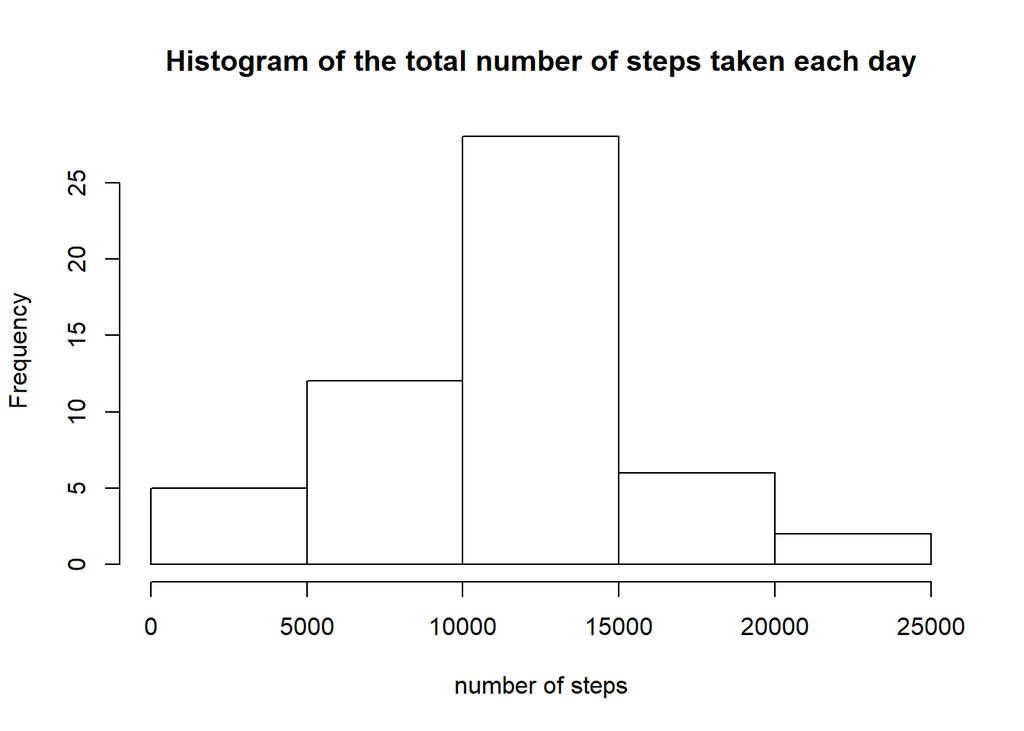

```r
activity1<-activity[(!is.na(activity$steps)),]
tstep<-with(activity1,tapply(steps,date,sum,na.rm=TRUE))
tstepf<-data.frame(date=names(tstep),sum=tstep)
tstepf<-tstepf[(!is.na(tstepf$sum)),]
hist(tstepf$sum,xlab="number of steps",main = "Histogram of the total number of steps taken each day")
```

#mean and median of steps

```r
as.integer(mean(tstepf$sum))
```

```
## [1] 10766
```

```r
as.integer(median(tstepf$sum))
```

```
## [1] 10765
```

# Q2 What is the average daily activity pattern?

# a.Make a time series plot (i.e. type = “l”) of the 5-minute interval (x-axis)

# and the average number of steps taken, averaged across all days (y-axis)

# b.Which 5-minute interval, on average across all the days in the dataset,

# contains the maximum number of steps?

# a

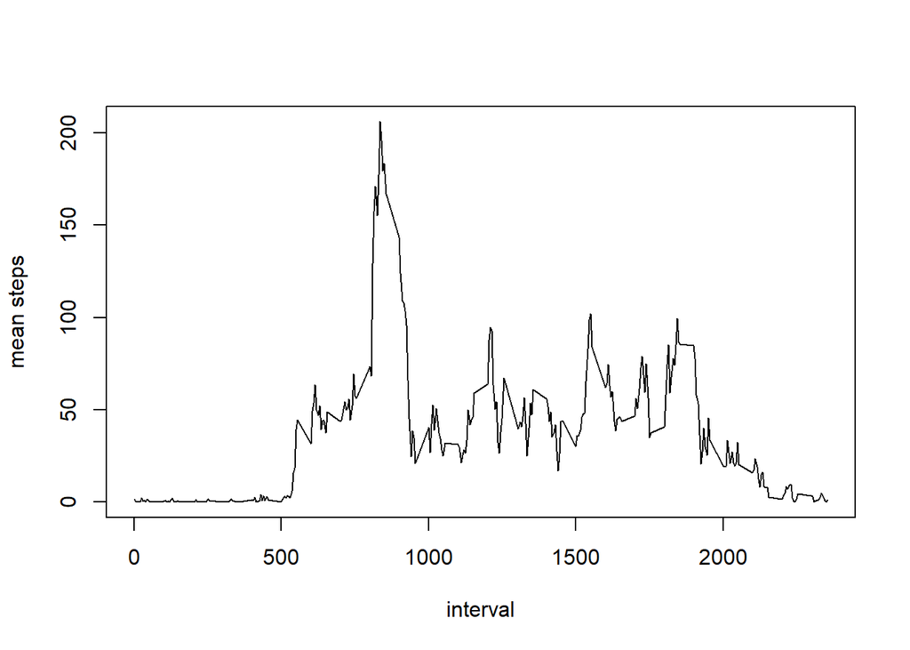

```r
tstepi<-with(activity1,tapply(steps,interval,mean,na.rm=TRUE))
plot(as.numeric(names(tstepi)),tstepi,xlab="interval",ylab="mean steps",type="l")
```

# b

```r
tstepi<-data.frame(interval=names(tstepi),mean=tstepi)
tstepi$mean<-as.numeric(tstepi$mean)
summary(tstepi)
```

```
##     interval        mean
##  0      :  1   Min.   :  0.000
##  10     :  1   1st Qu.:  2.486
##  100    :  1   Median : 34.113
##  1000   :  1   Mean   : 37.383
##  1005   :  1   3rd Qu.: 52.835
##  1010   :  1   Max.   :206.170
##  (Other):282
```

```r
subset(tstepi,mean>206)
```

```
##     interval     mean
## 835      835 206.1698
```

# Q3 Imputing missing values

# Note that there are a number of days/intervals where there are missing values

# (coded as NA). The presence of missing days may introduce bias into some

# calculations or summaries of the data.

# a. Calculate and report the total number of missing values in the dataset

# (i.e. the total number of rows with NAs)

# b. Devise a strategy for filling in all of the missing values in the dataset.

# The strategy does not need to be sophisticated. For example, you could use the

# mean/median for that day, or the mean for that 5-minute interval, etc.

# c. Create a new dataset that is equal to the original dataset but

# with the missing data filled in.

# d. Make a histogram of the total number of steps taken each day, and Calculate

# and report the mean and median total number of steps taken per day.

# Do these values differ from the estimates from the first part of

# the assignment? What is the impact of imputing missing data on the

# estimates of the total daily number of steps?

# a

```r
sum(is.na(activity$steps))
```

```
## [1] 2304
```

# b

```r
activity$steps<-as.character(activity$steps)
na<-subset(activity,is.na(activity$steps)=="TRUE",select=c(date,interval))
intmean<-merge(tstepi,na)
```

# c

```r
names(intmean)[2]<-"steps"
no_na<-subset(activity,is.na(activity$steps)=="FALSE")
```

# reorder the column

```r
no_na<-no_na[,c(2,3,1)]
intmean<-intmean[,c(3,1,2)]
rbd<-rbind(no_na,intmean)
rbd$date<-as.Date(rbd$date,tryFormats = c("%Y-%m-%d", "%Y/%m/%d"))
rbd$steps<-as.numeric(rbd$steps)
rbd$interval<-as.numeric(rbd$interval)
```

# d

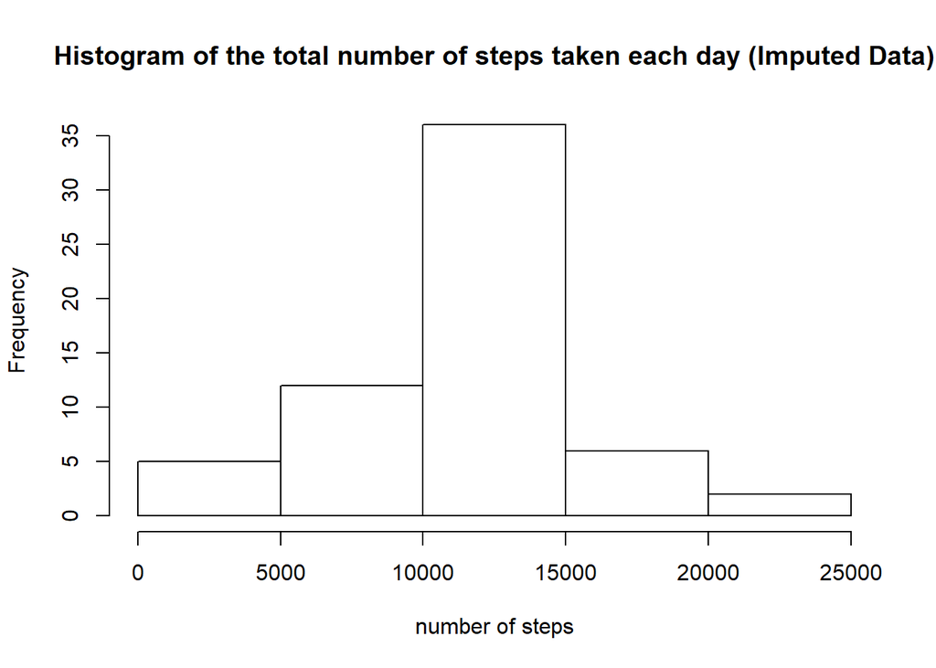

```r
tstepd<-with(rbd,tapply(steps,date,sum,na.rm=TRUE))
tstepd<-data.frame(date=names(tstepd),sum=tstepd)
hist(tstepd$sum,xlab="number of steps",main = "Histogram of the total number of steps taken each day (Imputed Data)")
```

```r
mean(tstepd$sum)
```

```
## [1] 10766.19
```

```r
median(tstepd$sum)
```

```
## [1] 10766.19
```

# The mean remains the same as prior to imputation, while the median value increased slightly.

# Q4

# Are there differences in activity patterns between weekdays and weekends?

# For this part the weekdays() function may be of some help here. Use the dataset with

# the filled-in missing values for this part.

# Create a new factor variable in the dataset with two levels

# – “weekday” and “weekend” indicating whether a given date is a weekday or weekend day.

# Make a panel plot containing a time series plot (i.e. type = “l”) of the 5-minute

# interval (x-axis) and the average number of steps taken, averaged across all weekday days or weekend days (y-axis).

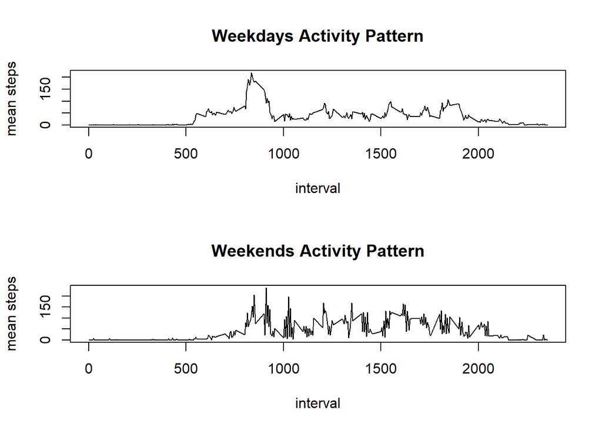

```r
rbd$weekday<-ifelse(weekdays(rbd$date)==c("Saturday","Sunday"),"weekend","weekday")
new<-arrange(rbd,interval)
weekday<-subset(new,weekday=="weekday")
weekend<-subset(new,weekday=="weekend")
weekdayplt<-with(weekday,tapply(steps,interval,mean,na.rm=TRUE))
weekendplt<-with(weekend,tapply(steps,interval,mean,na.rm=TRUE))

par(mfrow=c(2,1))
plot(as.numeric(names(weekdayplt)),weekdayplt,xlab="interval",ylab="mean steps", main = "Weekdays Activity Pattern", type="l")
plot(as.numeric(names(weekendplt)),weekendplt,xlab="interval",ylab="mean steps", main = "Weekends Activity Pattern", type="l")
```